# final_project

Annie Clark

December 8, 2018

1. Lit review
2. EDA/tidying
3. lit review and eda to help with variable selection

## missing values

```r
library(tidyverse)
cancer_data = read_csv(file = "./data/Cancer_Registry.csv") %>%
  janitor::clean_names()
names(cancer_data)
```

```
##  [1] "avg_ann_count"              "avg_deaths_per_year"
##  [3] "target_death_rate"          "incidence_rate"
##  [5] "med_income"                 "pop_est2015"
##  [7] "poverty_percent"            "study_per_cap"
##  [9] "binned_inc"                 "median_age"
## [11] "median_age_male"            "median_age_female"
## [13] "geography"                  "avg_household_size"
## [15] "percent_married"            "pct_no_hs18_24"
## [17] "pct_hs18_24"                "pct_some_col18_24"
## [19] "pct_bach_deg18_24"          "pct_hs25_over"
## [21] "pct_bach_deg25_over"        "pct_employed16_over"
## [23] "pct_unemployed16_over"      "pct_private_coverage"
## [25] "pct_private_coverage_alone" "pct_emp_priv_coverage"
## [27] "pct_public_coverage"        "pct_public_coverage_alone"
## [29] "pct_white"                  "pct_black"
## [31] "pct_asian"                  "pct_other_race"
## [33] "pct_married_households"     "birth_rate"
```

```r
cancer_data %>%
  filter(is.na(avg_ann_count)) %>%
  nrow()
```

```
## [1] 0
```

```r
cancer_data %>%
  filter(is.na(avg_deaths_per_year)) %>%
  nrow()
```

```
## [1] 0
```

```r
cancer_data %>%
  filter(is.na(target_death_rate)) %>%
  nrow()
```

```
## [1] 0
```

```r
cancer_data %>%
  filter(is.na(incidence_rate)) %>%
  nrow()
```

```
## [1] 0
```

```r
cancer_data %>%
  filter(is.na(med_income)) %>%
  nrow()
```

```
## [1] 0
```

```r
cancer_data %>%
  filter(is.na(pop_est2015)) %>%
  nrow()
```

```
## [1] 0
```

```r
cancer_data %>%
  filter(is.na(poverty_percent)) %>%
  nrow()
```

```
## [1] 0
```

```r
cancer_data %>%
  filter(is.na(study_per_cap)) %>%
  nrow()
```

```
## [1] 0
```

```r
cancer_data %>%
  filter(is.na(binned_inc)) %>%
  nrow()
```

```
## [1] 0
```

```r
cancer_data %>%
  filter(is.na(median_age)) %>%
  nrow()
```

```
## [1] 0
```

```r
cancer_data %>%
  filter(is.na(median_age_male)) %>%
  nrow()
```

```
## [1] 0
```

```r
cancer_data %>%
  filter(is.na(median_age_female)) %>%
  nrow()
```

```
## [1] 0
```

```r
cancer_data %>%
  filter(is.na(geography)) %>%
  nrow()
```

```
## [1] 0
```

```r
cancer_data %>%
  filter(is.na(avg_household_size)) %>%
  nrow()
```

```
## [1] 0
```

```r
cancer_data %>%
  filter(is.na(percent_married)) %>%
  nrow()
```

```
## [1] 0
```

```r
cancer_data %>%
  filter(is.na(pct_no_hs18_24)) %>%
  nrow()
```

```
## [1] 0
```

```r
cancer_data %>%
  filter(is.na(pct_hs18_24)) %>%
  nrow()
```

```
## [1] 0
```

```r
cancer_data %>%
  filter(is.na(pct_some_col18_24)) %>%
  nrow()
```

```
## [1] 2285
```

```r
##2285

cancer_data %>%
  filter(is.na(pct_bach_deg18_24)) %>%
  nrow()
```

```
## [1] 0
```

```r
cancer_data %>%
  filter(is.na(pct_hs25_over)) %>%
  nrow()
```

```
## [1] 0
```

```r
cancer_data %>%
  filter(is.na(pct_private_coverage)) %>%
  nrow()
```

```
## [1] 0
```

```r
cancer_data %>%
  filter(is.na(pct_employed16_over)) %>%
  nrow()
```

```
## [1] 152
```

```r
## 152

cancer_data %>%
  filter(is.na(pct_unemployed16_over)) %>%
  nrow()
```

```
## [1] 0
```

```r
cancer_data %>%
  filter(is.na(pct_private_coverage)) %>%
  nrow()
```

```
## [1] 0
```

```r
cancer_data %>%
  filter(is.na(pct_private_coverage_alone)) %>%
  nrow()
```

```
## [1] 609
```

```r
##609

cancer_data %>%
  filter(is.na(pct_emp_priv_coverage)) %>%
  nrow()
```

```
## [1] 0
```

```r
cancer_data %>%
  filter(is.na(pct_public_coverage)) %>%
  nrow()
```

```
## [1] 0
```

```r
cancer_data %>%
  filter(is.na(pct_public_coverage_alone)) %>%
  nrow()
```

```
## [1] 0
```

```r
cancer_data %>%
  filter(is.na(pct_white)) %>%
  nrow()
```

```
## [1] 0
```

```r
cancer_data %>%
  filter(is.na(pct_black)) %>%
  nrow()
```

```
## [1] 0
```

```r
cancer_data %>%
  filter(is.na(pct_asian)) %>%
  nrow()
```

```
## [1] 0
```

```r
cancer_data %>%
  filter(is.na(pct_other_race)) %>%
  nrow()
```

```
## [1] 0
```

```r
cancer_data %>%
  filter(is.na(pct_married_households)) %>%
  nrow()
```

```
## [1] 0
```

```r
cancer_data %>%
  filter(is.na(birth_rate)) %>%
  nrow()
```

```
## [1] 0
```

variables with missing data: - pct_private_coverage_alone (609 missing) 20% - pct_employed16_over (152 missing) 5% - pct_some_col18_24 (2285 missing) 75%

## correlation

```r
summary(cancer_data)
```

```
##  avg_ann_count     avg_deaths_per_year target_death_rate incidence_rate
##  Min.   :    6.0   Min.   :    3       Min.   : 59.7     Min.   : 201.3
##  1st Qu.:   76.0   1st Qu.:   28       1st Qu.:161.2     1st Qu.: 420.3
##  Median :  171.0   Median :   61       Median :178.1     Median : 453.5
##  Mean   :  606.3   Mean   :  186       Mean   :178.7     Mean   : 448.3
##  3rd Qu.:  518.0   3rd Qu.:  149       3rd Qu.:195.2     3rd Qu.: 480.9
##  Max.   :38150.0   Max.   :14010       Max.   :362.8     Max.   :1206.9
##
##    med_income      pop_est2015       poverty_percent study_per_cap
##  Min.   : 22640   Min.   :     827   Min.   : 3.20   Min.   :   0.00
##  1st Qu.: 38883   1st Qu.:   11684   1st Qu.:12.15   1st Qu.:   0.00
##  Median : 45207   Median :   26643   Median :15.90   Median :   0.00
##  Mean   : 47063   Mean   :  102637   Mean   :16.88   Mean   : 155.40
##  3rd Qu.: 52492   3rd Qu.:   68671   3rd Qu.:20.40   3rd Qu.:  83.65
##  Max.   :125635   Max.   :10170292   Max.   :47.40   Max.   :9762.31
##
##   binned_inc          median_age     median_age_male median_age_female
##  Length:3047        Min.   : 22.30   Min.   :22.40   Min.   :22.30
##  Class :character   1st Qu.: 37.70   1st Qu.:36.35   1st Qu.:39.10
##  Mode  :character   Median : 41.00   Median :39.60   Median :42.40
##                     Mean   : 45.27   Mean   :39.57   Mean   :42.15
##                     3rd Qu.: 44.00   3rd Qu.:42.50   3rd Qu.:45.30
##                     Max.   :624.00   Max.   :64.70   Max.   :65.70
##
##   geography         avg_household_size percent_married pct_no_hs18_24
##  Length:3047        Min.   :0.0221     Min.   :23.10   Min.   : 0.00
##  Class :character   1st Qu.:2.3700     1st Qu.:47.75   1st Qu.:12.80
##  Mode  :character   Median :2.5000     Median :52.40   Median :17.10
##                     Mean   :2.4797     Mean   :51.77   Mean   :18.22
##                     3rd Qu.:2.6300     3rd Qu.:56.40   3rd Qu.:22.70
##                     Max.   :3.9700     Max.   :72.50   Max.   :64.10
##
##   pct_hs18_24   pct_some_col18_24 pct_bach_deg18_24 pct_hs25_over
##  Min.   : 0.0   Min.   : 7.10     Min.   : 0.000    Min.   : 7.50
##  1st Qu.:29.2   1st Qu.:34.00     1st Qu.: 3.100    1st Qu.:30.40
##  Median :34.7   Median :40.40     Median : 5.400    Median :35.30
##  Mean   :35.0   Mean   :40.98     Mean   : 6.158    Mean   :34.80
##  3rd Qu.:40.7   3rd Qu.:46.40     3rd Qu.: 8.200    3rd Qu.:39.65
##  Max.   :72.5   Max.   :79.00     Max.   :51.800    Max.   :54.80
##                 NA's   :2285
```

[output cut: 25 more lines]

```
##  Min.   : 0.0000   Min.   : 0.0000   Min.   : 0.0000
##  1st Qu.: 0.6207   1st Qu.: 0.2542   1st Qu.: 0.2952
##  Median : 2.2476   Median : 0.5498   Median : 0.8262
##  Mean   : 9.1080   Mean   : 1.2540   Mean   : 1.9835
##  3rd Qu.:10.5097   3rd Qu.: 1.2210   3rd Qu.: 2.1780
##  Max.   :85.9478   Max.   :42.6194   Max.   :41.9303
##
##  pct_married_households   birth_rate
##  Min.   :22.99          Min.   : 0.000
##  1st Qu.:47.76          1st Qu.: 4.521
##  Median :51.67          Median : 5.381
##  Mean   :51.24          Mean   : 5.640
##  3rd Qu.:55.40          3rd Qu.: 6.494
##  Max.   :78.08          Max.   :21.326
##
```

```r
## binned_inc - character
## geography - character

cancer_data %>%
  select(-binned_inc, -geography) %>% ##remove characters
  cor() %>%
  as_tibble()
```

```
## # A tibble: 32 x 32
##    avg_ann_count avg_deaths_per_~ target_death_ra~ incidence_rate
##            <dbl>            <dbl>            <dbl>          <dbl>
##  1        1                0.939          -0.144          0.0736
##  2        0.939            1              -0.0907         0.0627
##  3       -0.144           -0.0907          1              0.449
##  4        0.0736           0.0627          0.449          1
##  5        0.269            0.223          -0.429         -0.00104
##  6        0.927            0.978          -0.120          0.0269
##  7       -0.136           -0.0669          0.429          0.00905
##  8        0.0821           0.0635         -0.0223         0.0773
##  9       -0.0241          -0.0246          0.00438        0.0181
## 10       -0.125           -0.148          -0.0219        -0.0147
## # ... with 22 more rows, and 28 more variables: med_income <dbl>,
## #   pop_est2015 <dbl>, poverty_percent <dbl>, study_per_cap <dbl>,
## #   median_age <dbl>, median_age_male <dbl>, median_age_female <dbl>,
## #   avg_household_size <dbl>, percent_married <dbl>, pct_no_hs18_24 <dbl>,
## #   pct_hs18_24 <dbl>, pct_some_col18_24 <dbl>, pct_bach_deg18_24 <dbl>,
## #   pct_hs25_over <dbl>, pct_bach_deg25_over <dbl>,
## #   pct_employed16_over <dbl>, pct_unemployed16_over <dbl>,
## #   pct_private_coverage <dbl>, pct_private_coverage_alone <dbl>,
## #   pct_emp_priv_coverage <dbl>, pct_public_coverage <dbl>,
## #   pct_public_coverage_alone <dbl>, pct_white <dbl>, pct_black <dbl>,
## #   pct_asian <dbl>, pct_other_race <dbl>, pct_married_households <dbl>,
## #   birth_rate <dbl>
```

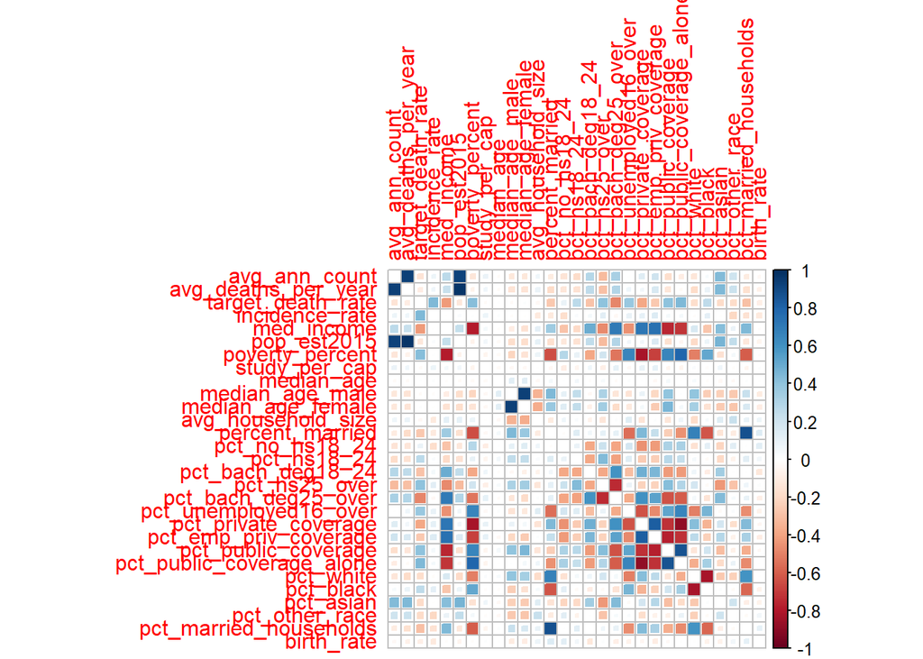

```r
library(corrplot)
cancer_data %>%
  select(-binned_inc, -geography,
         -pct_private_coverage_alone, -pct_employed16_over, -pct_some_col18_24) %>% ##remove characters
  cor() %>%
  corrplot(., method = "square", insig = "blank", diag=FALSE, number.cex = .7)
```

There are clusters of variables that look to be correlated with other variables.

If we choose to use any other following variables, we need to check what other variables are in the model to make sure there is not a multicollinearity issue:

- med_income
- poverty_percent
- pct_public_coverage_along
- pct_public_coverage
- pct_emp_priv_coverage
- pct_private_coverage

## scatterplots of target_death_rate vs. risk factors

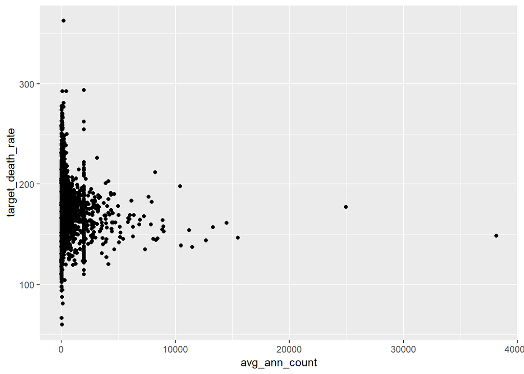

```r
cancer_data %>%
  ggplot(aes(x = avg_ann_count, y = target_death_rate)) +
  geom_point()
```

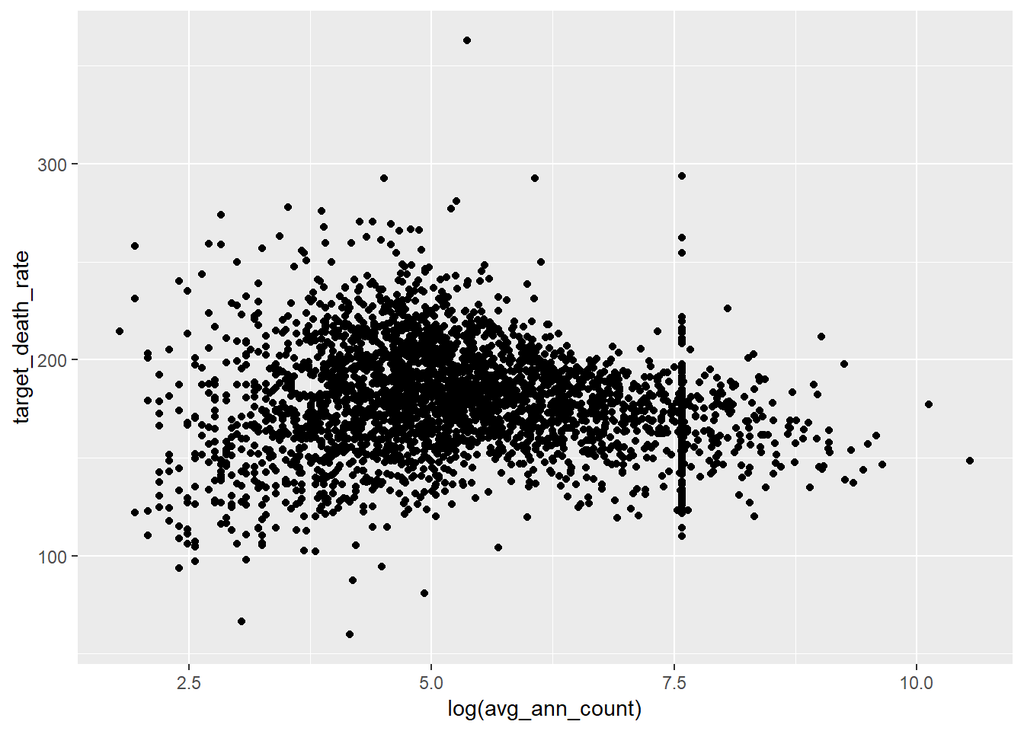

```r
## looks like needs a log transformation

cancer_data %>%
  ggplot(aes(x = log(avg_ann_count), y = target_death_rate)) +
  geom_point()
```

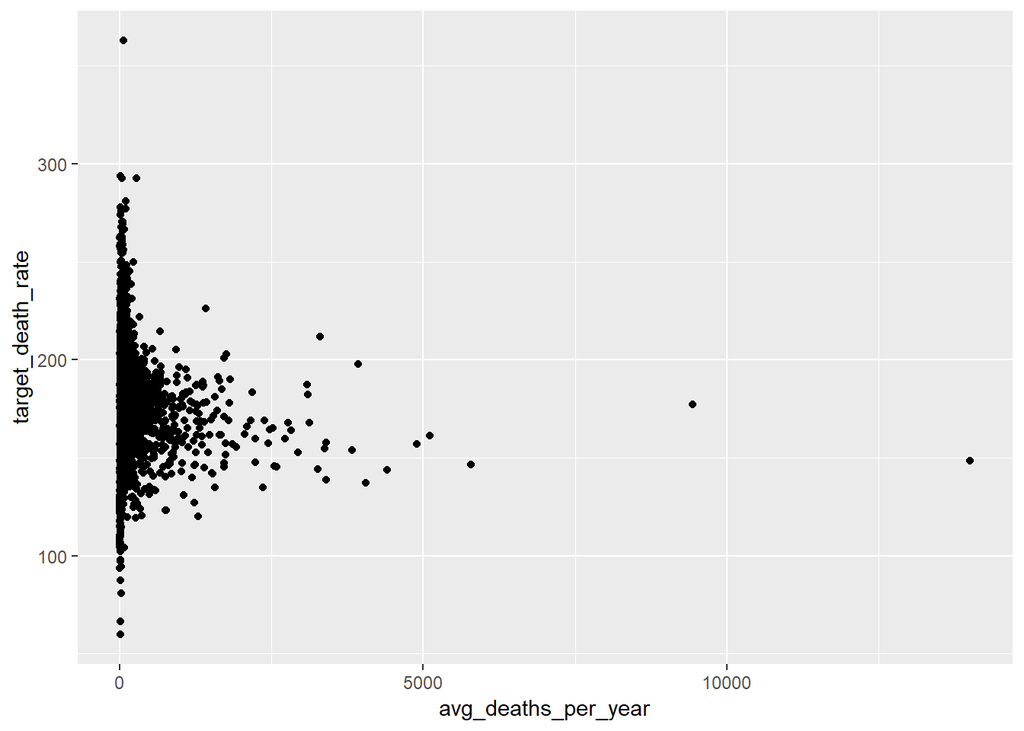

```r
## looks curvilinear


cancer_data %>%
  ggplot(aes(x = avg_deaths_per_year, y = target_death_rate)) +
  geom_point()
```

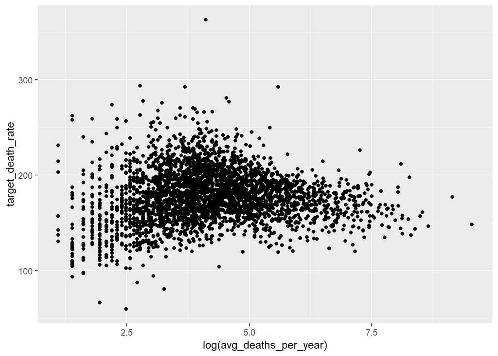

```r
## looks like needs a log transformation


cancer_data %>%
  ggplot(aes(x = log(avg_deaths_per_year), y = target_death_rate)) +
  geom_point()
```

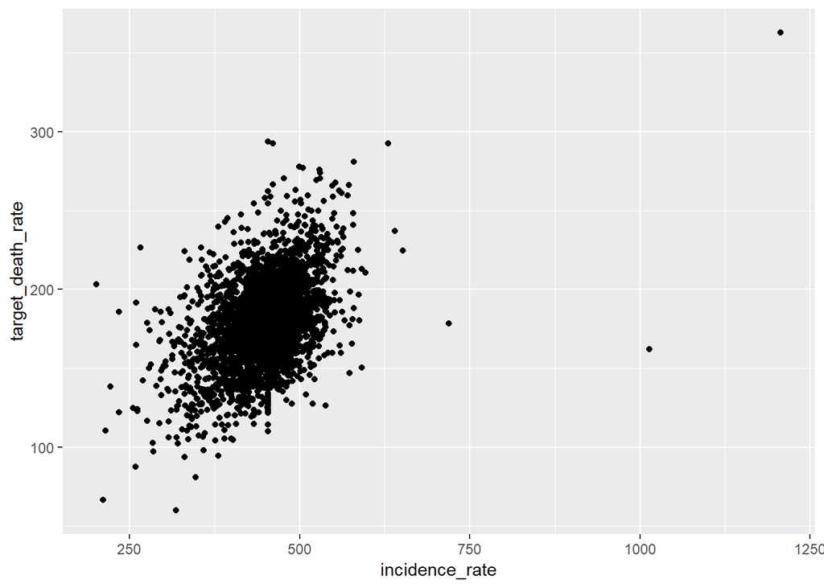

```r
## still looks curvilinear


cancer_data %>%
  ggplot(aes(x = incidence_rate, y = target_death_rate)) +
  geom_point()
```

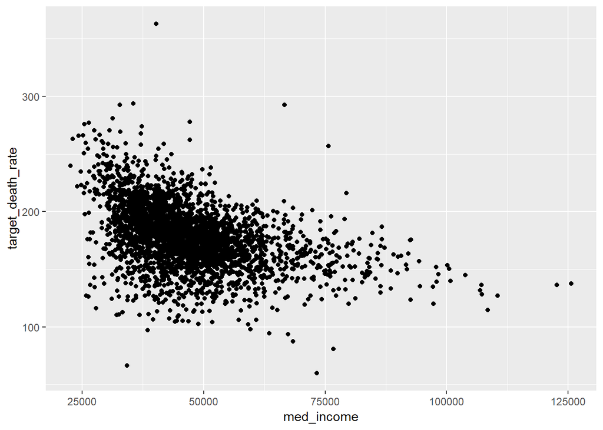

```r
## linear, with some x extreme outliers

cancer_data %>%
  ggplot(aes(x = med_income, y = target_death_rate)) +
  geom_point()
```

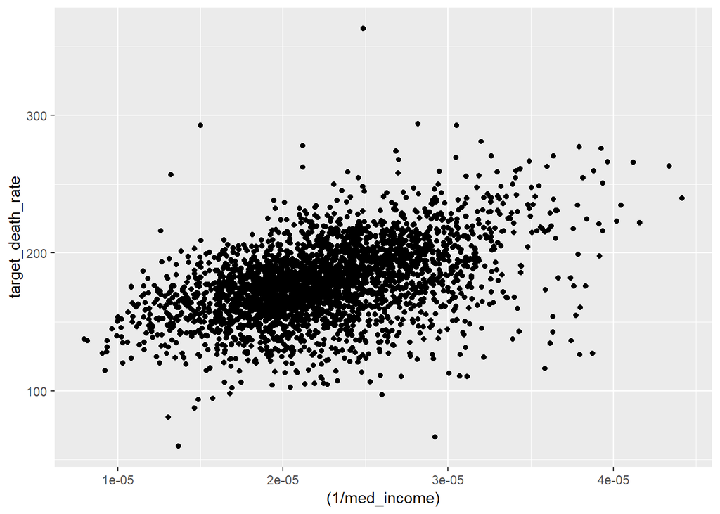

```r
## looks a little curvilinear -- need to do transformation

cancer_data %>%
  ggplot(aes(x = (1/med_income), y = target_death_rate)) +
  geom_point()
```

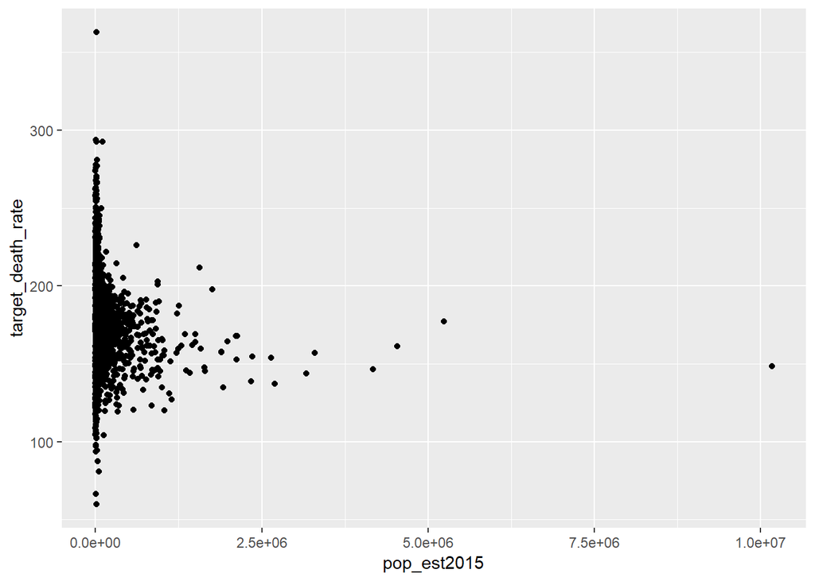

```r
## looks linear...

cancer_data %>%
  ggplot(aes(x = pop_est2015, y = target_death_rate)) +
  geom_point()
```

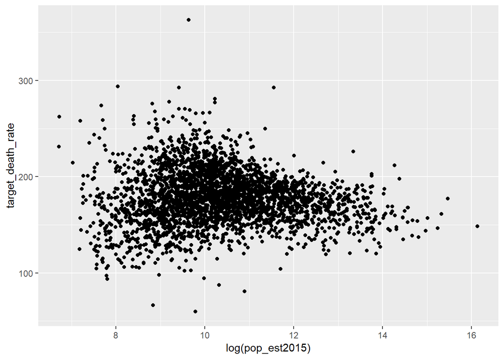

```r
## need to do log transformation

cancer_data %>%
  ggplot(aes(x = log(pop_est2015), y = target_death_rate)) +
  geom_point()
```

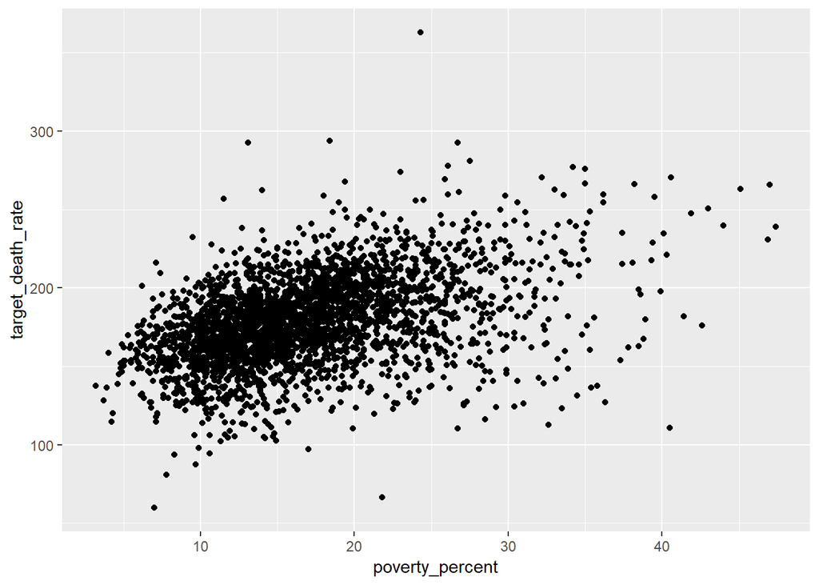

```r
## still looks a little curvilinear

cancer_data %>%
  ggplot(aes(x = poverty_percent, y = target_death_rate)) +
  geom_point()
```

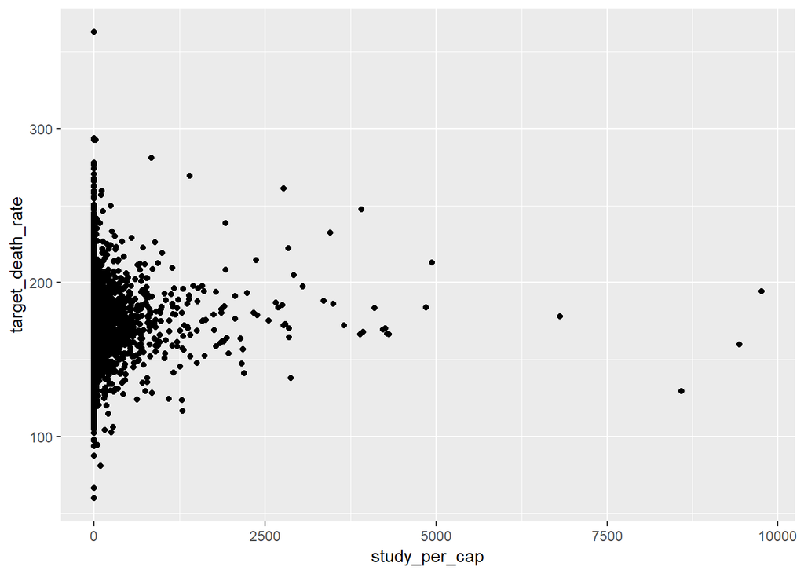

```r
## looks linear

cancer_data %>%
  ggplot(aes(x = study_per_cap, y = target_death_rate)) +
  geom_point()
```

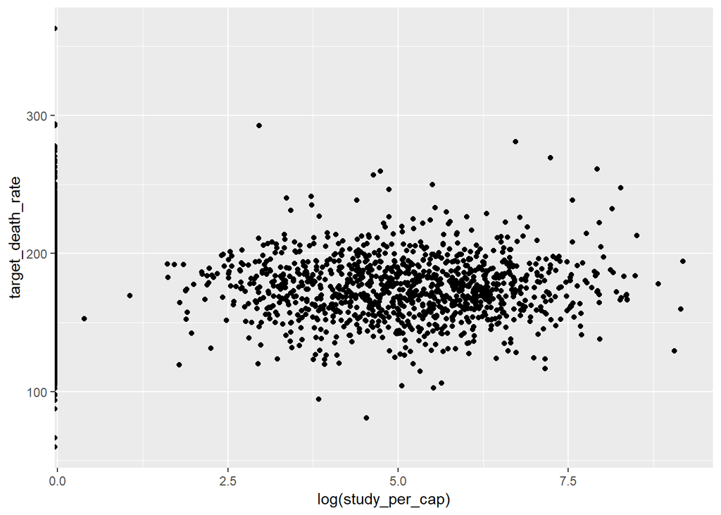

```r
## need to do a log transformation

cancer_data %>%
  ggplot(aes(x = log(study_per_cap), y = target_death_rate)) +
  geom_point()
```

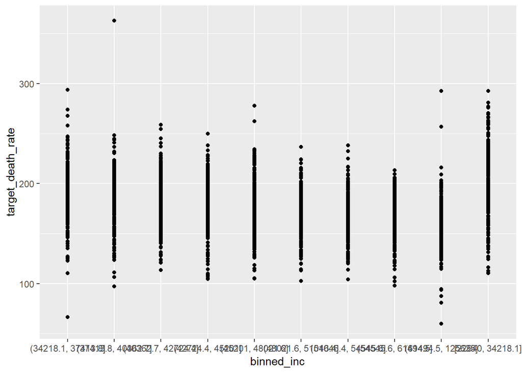

```r
## looks linear, but also has a weird 0 varlies all along the y values

cancer_data %>%
  ggplot(aes(x = binned_inc, y = target_death_rate)) +
  geom_point()
```

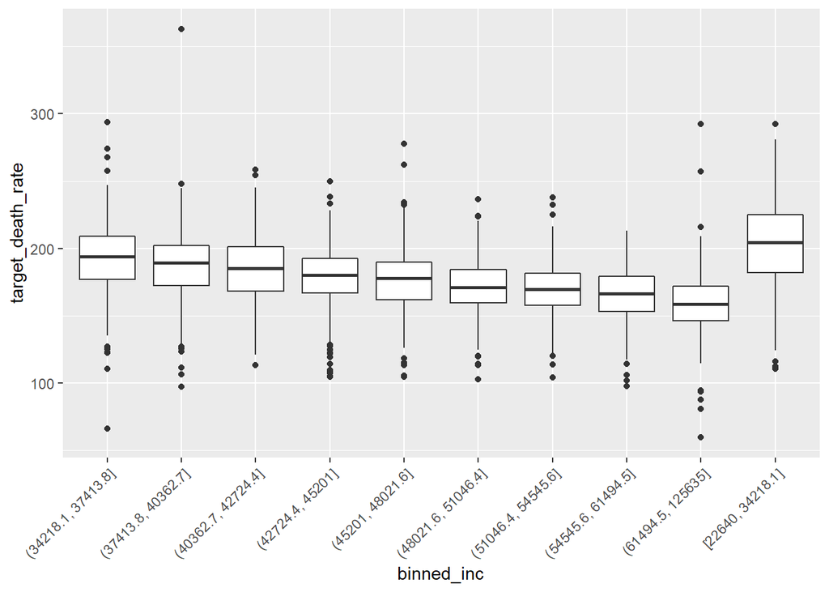

```r
## looks randomly scattered throughout the bins.. should do boxplot

cancer_data %>%
  ggplot(aes(x = binned_inc,  y = target_death_rate)) +
  geom_boxplot() +
  theme(axis.text.x=element_text(angle=45,hjust=1))
```

```r
cancer_data %>%
  group_by(binned_inc) %>%
  summarise(n = n())
```

```
## # A tibble: 10 x 2
##    binned_inc             n
##    <chr>              <int>
##  1 (34218.1, 37413.8]   304
##  2 (37413.8, 40362.7]   304
##  3 (40362.7, 42724.4]   304
##  4 (42724.4, 45201]     305
##  5 (45201, 48021.6]     306
##  6 (48021.6, 51046.4]   305
##  7 (51046.4, 54545.6]   305
##  8 (54545.6, 61494.5]   306
##  9 (61494.5, 125635]    302
## 10 [22640, 34218.1]     306
```

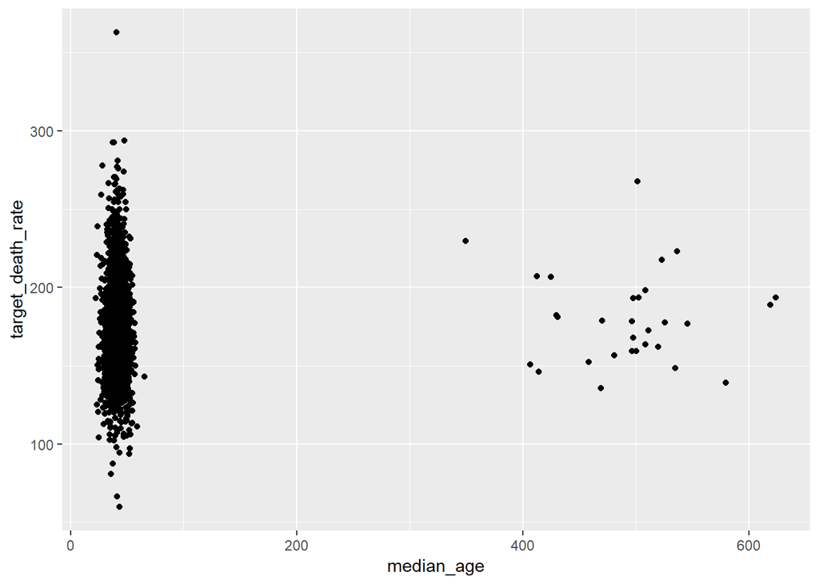

```r
## oddly a similar number of observations per bin...

cancer_data %>%
  ggplot(aes(x = median_age, y = target_death_rate)) +
  geom_point()
```

```r
## this looks like an issue - let's look further into median_age

cancer_data %>%
  group_by(round(median_age)) %>%
  summarize(n = n())
```

```
## # A tibble: 65 x 2
##    `round(median_age)`     n
##                  <dbl> <int>
##  1                  22     1
##  2                  23     2
##  3                  24     4
##  4                  25     6
##  5                  26     8
##  6                  27     6
##  7                  28    14
##  8                  29    17
##  9                  30    39
## 10                  31    32
## # ... with 55 more rows
```

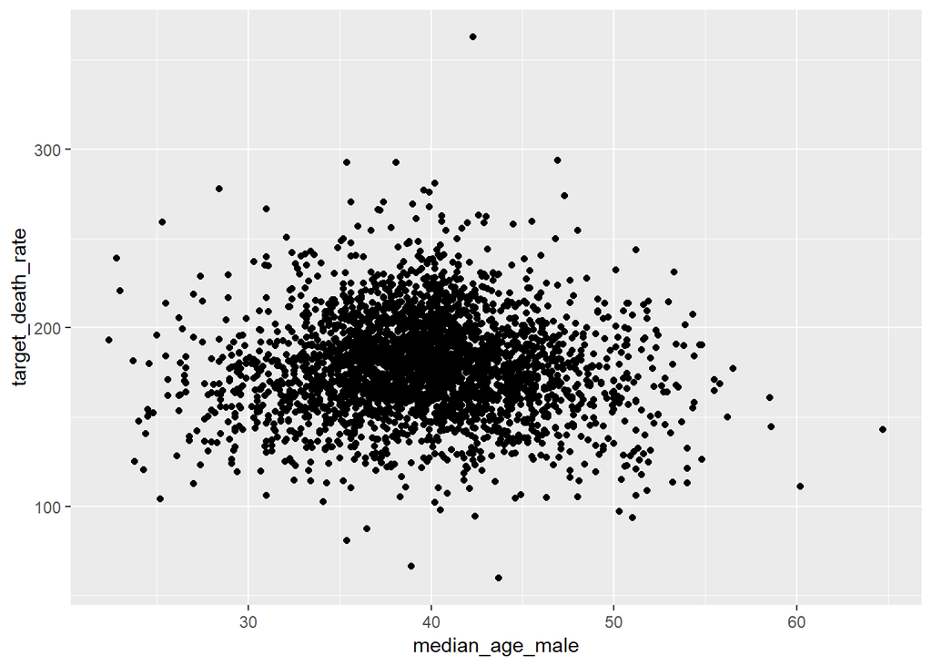

```r
## there are ages that go from 22 - 65 and then from 349 - 624. This is an error with the data

cancer_data %>%
  ggplot(aes(x = median_age_male, y = target_death_rate)) +
  geom_point()
```

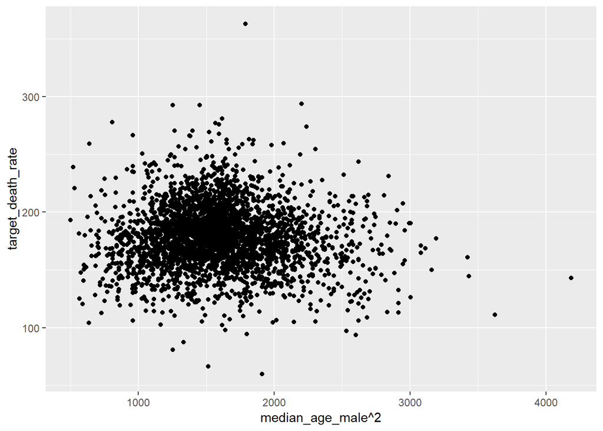

```r
## looks like curvilinear, let's try transformation

cancer_data %>%
  ggplot(aes(x = median_age_male^2, y = target_death_rate)) +
  geom_point()
```

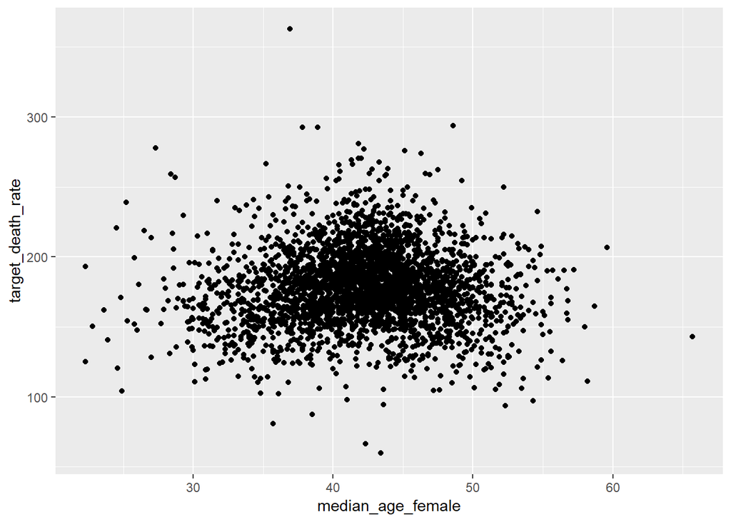

```r
## tried ^2, ^3, inverse, log, nothing really makes it look better

cancer_data %>%
  ggplot(aes(x = median_age_female, y = target_death_rate)) +
  geom_point()
```

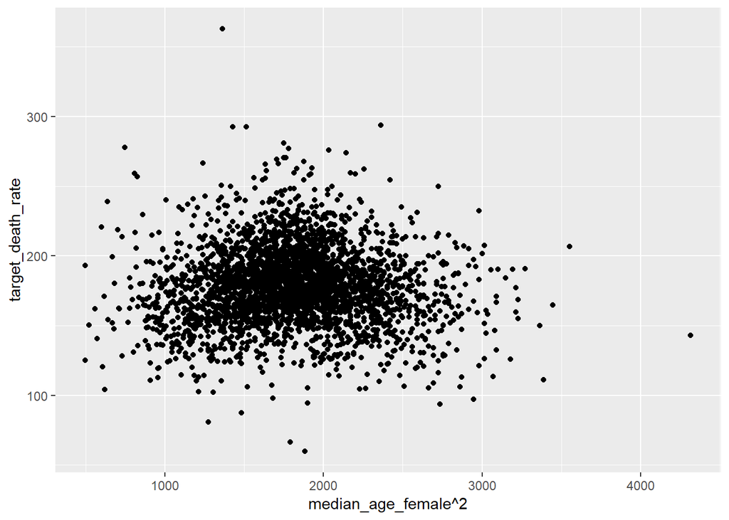

```r
## similar to male median age


cancer_data %>%
  ggplot(aes(x = median_age_female^2, y = target_death_rate)) +
  geom_point()
```

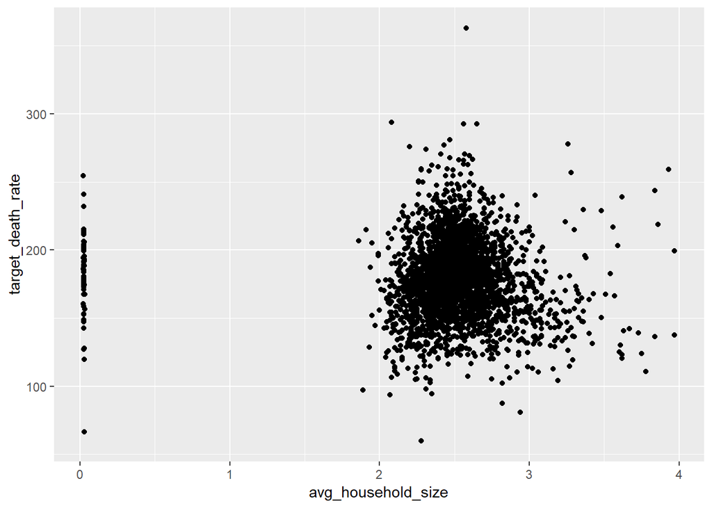

```r
## tried ^2, ^3, inverse, log, nothing really makes it look better



cancer_data %>%
  ggplot(aes(x = avg_household_size, y = target_death_rate)) +
  geom_point()
```

```r
## there are a ton of 0 values; this coule potentially be a data quality issue

cancer_data %>%
  count(avg_household_size)
```

```
## # A tibble: 199 x 2
##    avg_household_size     n
##                 <dbl> <int>
##  1             0.0221     1
##  2             0.0222     2
##  3             0.0225     1
##  4             0.023      1
##  5             0.0236     1
##  6             0.0237     2
##  7             0.0239     1
##  8             0.024      3
##  9             0.0241     2
## 10             0.0242     3
## # ... with 189 more rows
```

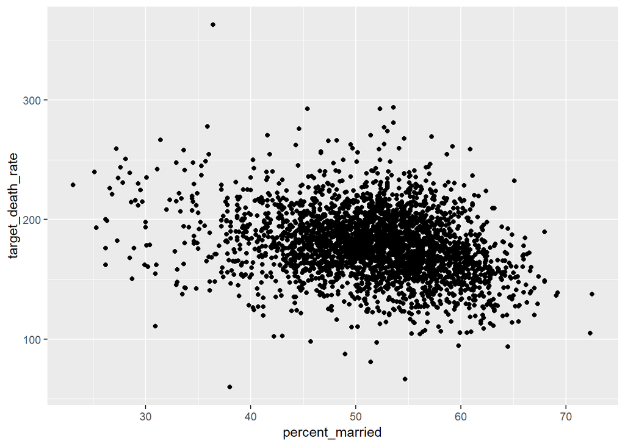

```r
## it looks like there are a ton of 0.02.... not sure what this means?


cancer_data %>%
  ggplot(aes(x = percent_married, y = target_death_rate)) +
  geom_point()
```

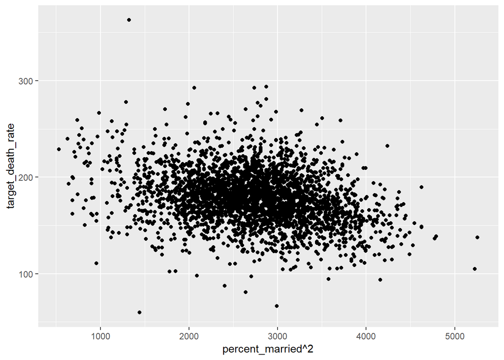

```r
## looks linear; potentially curilinear


cancer_data %>%
  ggplot(aes(x = percent_married^2, y = target_death_rate)) +
  geom_point()
```

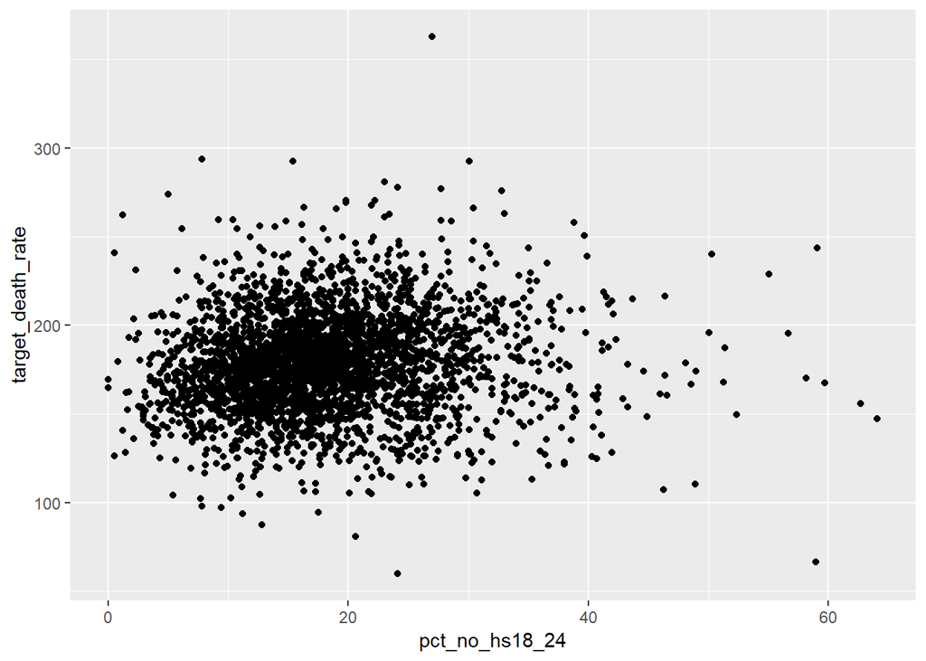

```r
## looks better

cancer_data %>%
  ggplot(aes(x = pct_no_hs18_24, y = target_death_rate)) +
  geom_point()
```

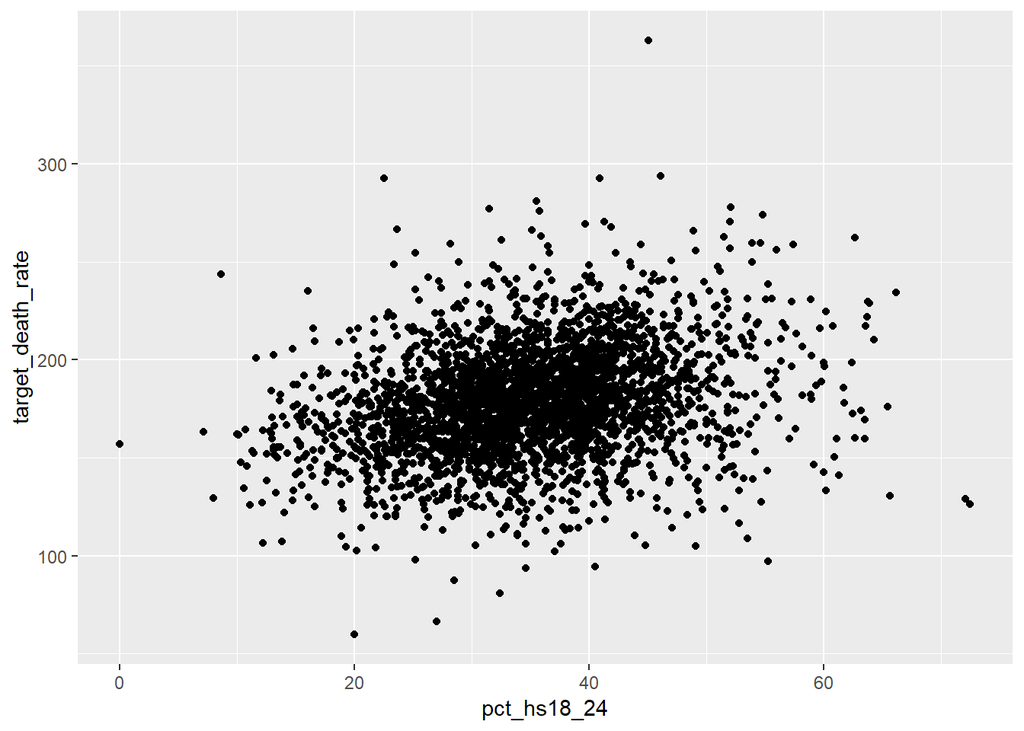

```r
## looks linear; potentially curilinear


cancer_data %>%
  ggplot(aes(x = pct_hs18_24, y = target_death_rate)) +
  geom_point()
```

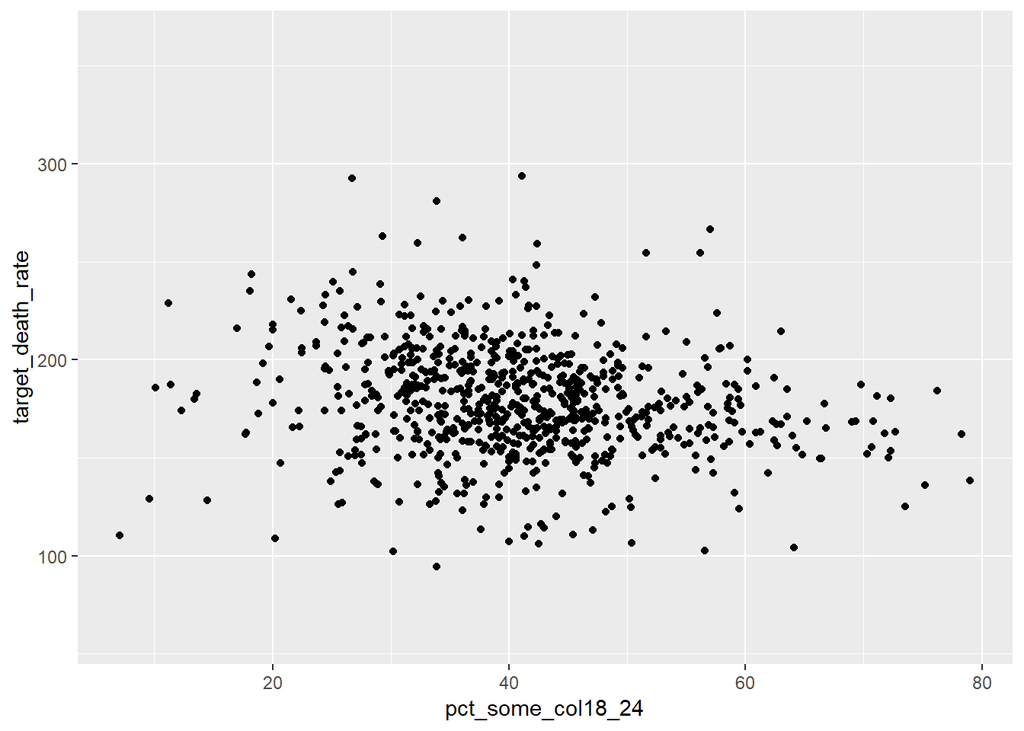

```r
cancer_data %>%
  ggplot(aes(x = pct_some_col18_24, y = target_death_rate)) +
  geom_point()
```

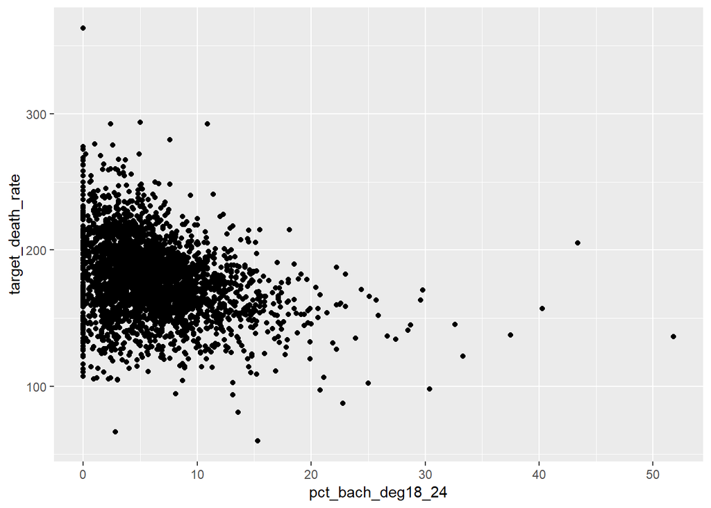

```r
## linear, but missing values

cancer_data %>%
  ggplot(aes(x = pct_bach_deg18_24, y = target_death_rate)) +
  geom_point()
```

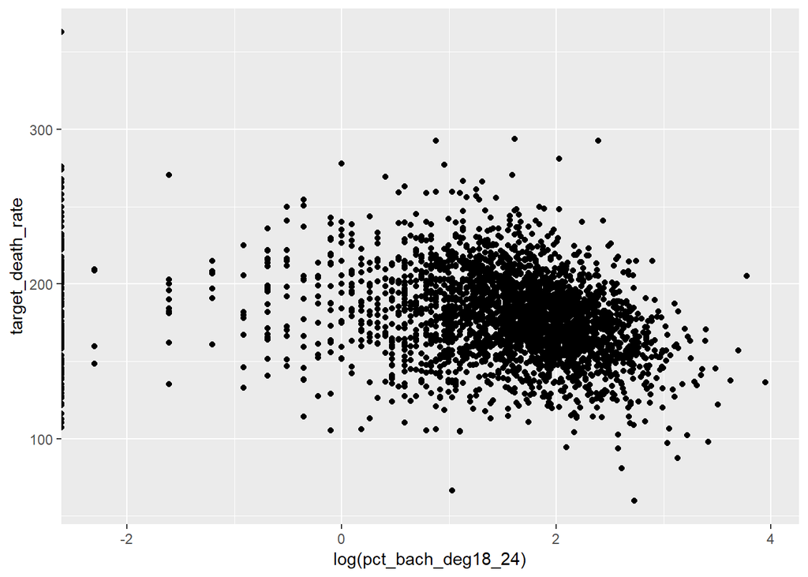

```r
## log transformation

cancer_data %>%
  ggplot(aes(x = log(pct_bach_deg18_24), y = target_death_rate)) +
  geom_point()
```

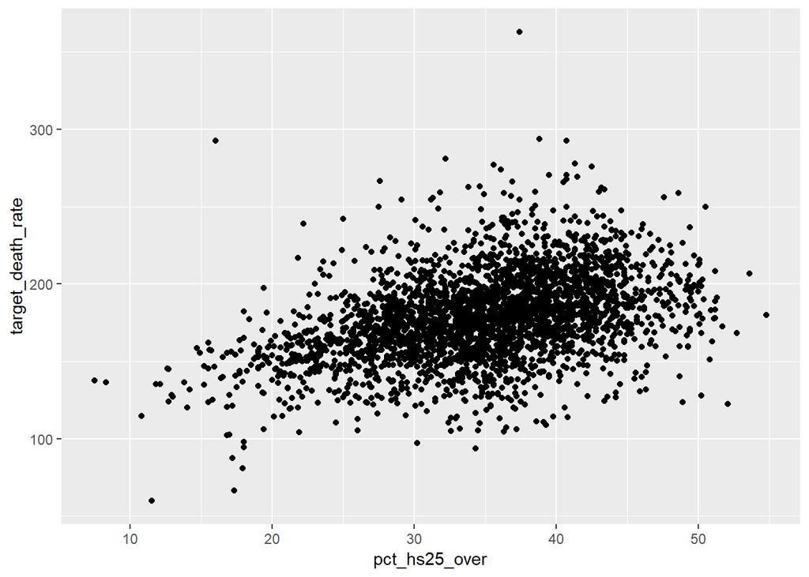

```r
## makes it a little better, but zero values are an issue (inverse and squared do not work)


cancer_data %>%
  ggplot(aes(x = pct_hs25_over, y = target_death_rate)) +
  geom_point()
```

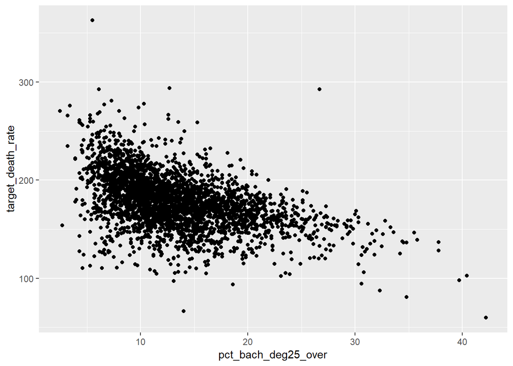

```r
## looks linear

cancer_data %>%
  ggplot(aes(x = pct_bach_deg25_over, y = target_death_rate)) +
  geom_point()
```